# Reproducible Research Course Project 1

Ran Tang

3/17/2021

# Markdown for Reproducible Research Course Project 1

```r
library(dplyr)
```

```r
library(ggplot2)
library(lubridate)
```

# Loading and preprocessing the data

```r
fname <- "repdata_data_activity.zip"
furl <- "https://d396qusza40orc.cloudfront.net/repdata%2Fdata%2Factivity.zip"

if (!file.exists(fname)){
  download.file(furl, fname, method="curl")
}

if (!file.exists("activity")) {
  unzip(fname)
}

#read data into R
activity <- read.csv("activity.csv")
```

# What is mean total number of steps taken per day?

```r
stepsPerDay<-aggregate(activity$steps~activity$date, FUN=mean, na.rm = TRUE)
head(stepsPerDay)
```

```
##   activity$date activity$steps
## 1    2012-10-02        0.43750
## 2    2012-10-03       39.41667
## 3    2012-10-04       42.06944
## 4    2012-10-05       46.15972
## 5    2012-10-06       53.54167
## 6    2012-10-07       38.24653
```

[figure not shown]

```r
activity$date <- as.Date(activity$date, "%Y-%m-%d")
hist(stepsPerDay$`activity$steps`,
    main="Total Steps Taken Each Day",
    xlab="# Steps per Day",
    ylab = "Interval",
    col="blue")
```

```r
stepsMean <- mean(stepsPerDay$`activity$steps`)
stepsMean
```

```
## [1] 37.3826
```

```r
stepsMedian <- median(stepsPerDay$`activity$steps`)
stepsMedian
```

```
## [1] 37.37847
```

# What is the average daily activity pattern?

### Make a time series plot (i.e. type = “l”) of the 5-minute interval (x-axis) and the average number of steps taken, averaged across all days (y-axis)

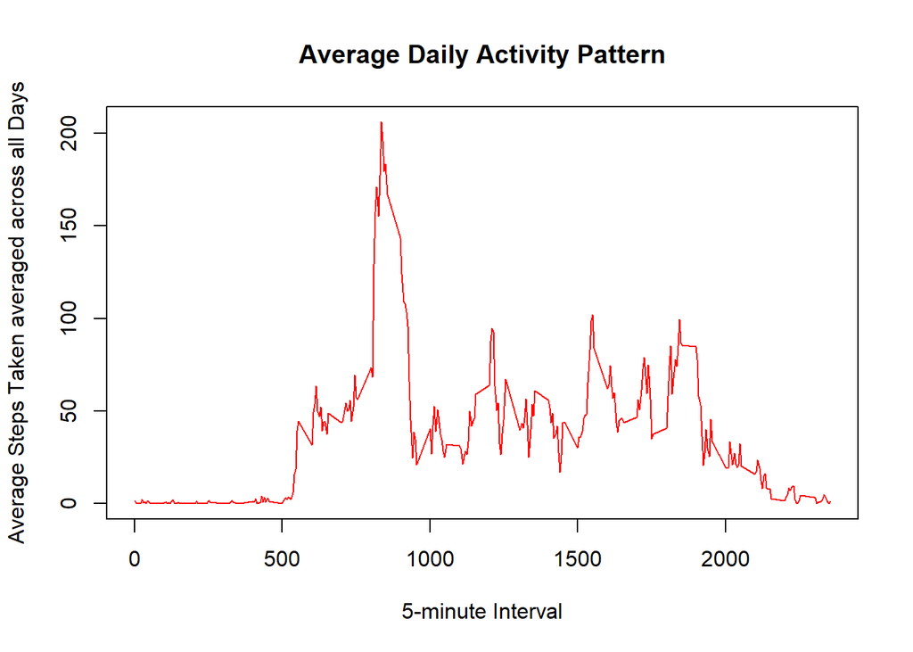

```r
five <- aggregate(activity$steps ~ activity$interval, FUN = mean, na.rm = TRUE)
plot(x = five$`activity$interval`, y = five$`activity$steps`,
    type = "l",
    col = "red",
    xlab = "5-minute Interval",
    ylab = "Average Steps Taken averaged across all Days",
    main = "Average Daily Activity Pattern")
```

### Which 5-minute interval, on average across all the days in the dataset, contains the maximum number of steps?

```r
stepmax <- five$`activity$interval`[which.max(five$`activity$steps`)]
stepmax
```

```
## [1] 835
```

# Imputing missing values

### Calculate and report the total number of missing values in the dataset (i.e. the total number of rows with NAs)

```r
missing<- sum(is.na(activity$steps))
missing
```

```
## [1] 2304
```

### Devise a strategy for filling in all of the missing values in the dataset. The strategy does not need to be sophisticated. For example, you could use the mean/median for that day, or the mean for that 5-minute interval, etc.

### Create a new dataset that is equal to the original dataset but with the missing data filled in.

```r
#find mean interval
meanInterval <-  aggregate(steps ~ interval, activity, FUN=mean)
activity2 <- merge(x=activity, y=meanInterval, by="interval")
#replace missing values with mean interval
activity2$steps <- ifelse(is.na(activity2$steps.x), activity2$steps.y, activity2$steps.x)

#create new dataset with missing data filled in
activity2 <- select(activity2, steps, date, interval)
head(activity2)
```

```
##      steps       date interval
## 1 1.716981 2012-10-01        0
## 2 0.000000 2012-11-23        0
## 3 0.000000 2012-10-28        0
## 4 0.000000 2012-11-06        0
## 5 0.000000 2012-11-24        0
## 6 0.000000 2012-11-15        0
```

[figure not shown]

```r
#make histogram
par(mfrow=c(1,2))
stepsPerDay2 <-aggregate(activity2$steps~activity2$date, FUN=mean, na.rm = TRUE)
hist(stepsPerDay2$`activity2$steps`,
    main="Total Steps Taken/Day (Na Replaced)",
    xlab="# Steps per Day",
    ylab = "Interval",
    col="blue")

#recreate original histogram
hist(stepsPerDay$`activity$steps`,
    main="Total Steps Taken/Day (Original)",
    xlab="# Steps per Day",
    ylab = "Interval",
    col="red")
```

```r
#find mean and median, see impact of imputing missing data
summary(stepsPerDay)
```

```
##  activity$date      activity$steps
##  Length:53          Min.   : 0.1424
##  Class :character   1st Qu.:30.6979
##  Mode  :character   Median :37.3785
##                     Mean   :37.3826
##                     3rd Qu.:46.1597
##                     Max.   :73.5903
```

```r
summary(stepsPerDay2)
```

```
##  activity2$date       activity2$steps
##  Min.   :2012-10-01   Min.   : 0.1424
##  1st Qu.:2012-10-16   1st Qu.:34.0938
##  Median :2012-10-31   Median :37.3826
##  Mean   :2012-10-31   Mean   :37.3826
##  3rd Qu.:2012-11-15   3rd Qu.:44.4826
##  Max.   :2012-11-30   Max.   :73.5903
```

The mean is unsurprisingly identical, but the median is slightly different and the quantiles differ

# Are there differences in activity patterns between weekdays and weekends?

### Create a new factor variable in the dataset with two levels – “weekday” and “weekend” indicating whether a given date is a weekday or weekend day.

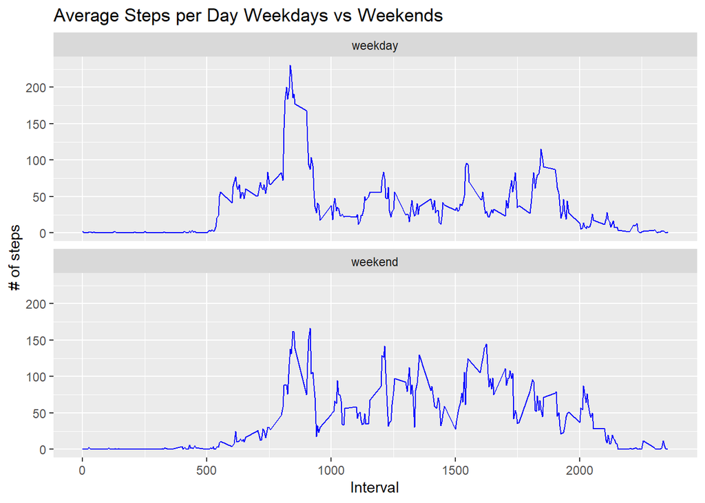

```r
#create factor variable weekday for weekday vs weekend
activity2$dayofweek <- weekdays(activity2$date)
activity2$weekday<- ifelse(activity2$dayofweek == "Saturday" | activity2$dayofweek == "Sunday", "weekend","weekday" )

stepsPerDay2 <-aggregate(activity2$steps~activity2$interval + activity2$weekday, FUN=mean, na.rm = TRUE)

#plot weekday vs weekend side by side
g <- ggplot(stepsPerDay2, aes(x=`activity2$interval`, y=`activity2$steps`)) +
  geom_line(color="blue") +
  facet_wrap(~`activity2$weekday`, nrow=2) +
  labs(title = "Average Steps per Day Weekdays vs Weekends", x="Interval", y="# of steps")
print(g)
```

There appears to be signficantly different activity patterns between weekdays and weekends